# Generalized Linear Models

# Overview

- Generalizing the Linear Model
- Logistic Regression
- Poisson Regression
- R investigation

For further reading, see [JWHT], pp. 129-141, 164-170.

# Generalizing the Linear Model

## Limitations of the Linear Regression Model

In **Linear Regression**, we model $f(X)$ with:

$$Y = \beta_0 + \beta_1 X_1 +\beta_2 X_2 + \cdots + \beta_p X_p + \epsilon$$

- $Y$ is assumed to be a continuous random variable.
  - What if we have a discrete response (e.g., classification)
- $\epsilon$ is assumed to be Gaussian (e.g., normally distributed) with mean zero.
  - Doesn’t make sense if $Y$ is discrete, or bounded below.

## Regression and Conditional Expectation

- Linear regression: $E(Y \mid X_1, X_2, \ldots, X_p) = \beta_1 + \beta_1X_1 + \cdots + \beta_pX^p$
  - Assumes that the conditional mean is *linear* in the predictors.
- Generalized linear regression: The conditional mean *can be transformed to be* a linear function of the predictors.
  - $\eta\left(E(Y \mid X_1, X_2, \ldots, X_p) \right) = \beta_0 + \beta_1X_1 + \cdots + \beta_pX_p$
  - $\eta$ is called a **link function**.
- The distribution of $Y \mid X$ may not be Gaussian (or even continuous).
  - In **logistic regression**, it is Bernoulli (i.e., binomial, $n = 1$)
  - In **Poisson regression**, it is Poisson.
- The coefficients can be found by maximizing a **likelihood function**.
  $$\ell(\beta_0, \beta_1, \ldots, \beta_p \mid \text{the training data})$$
  - This function assumes the observations are **independent**.

# Logistic Regression

## Binary Response Variable

Suppose we want to predict $Y$ from a single variable $X$, and $Y$ is **binary** (i.e., 0/1).

```r
library(ISLR2)
library(tidyverse)
glimpse(Default)
```

```
Rows: 10,000
Columns: 4
$ default <fct> No, No, No, No, No, No, No, No, No, No, No, No, No, No, No, No, No, No, No, No, No…
$ student <fct> No, Yes, No, No, No, Yes, No, Yes, No, No, Yes, Yes, No, No, No, No, No, Yes, No, …
$ balance <dbl> 729.5265, 817.1804, 1073.5492, 529.2506, 785.6559, 919.5885, 825.5133, 808.6675, 1…
$ income  <dbl> 44361.625, 12106.135, 31767.139, 35704.494, 38463.496, 7491.559, 24905.227, 17600.…
```

## Factors not allowed in linear regression

```r
defMod1 <- lm(default ~ balance, data = Default)
summary(defMod1)
```

```
Call:
lm(formula = default ~ balance, data = Default)

Residuals:
Error in quantile.default(resid) : (unordered) factors are not allowed
In addition: Warning message:
In Ops.factor(r, 2) : ‘^’ not meaningful for factors
```

## Kludge: Make a 0/1 variable

```r
DefaultK <- Default %>%
  mutate(defBin = ifelse(default == "No", 0, 1))
defMod1 <- lm(defBin ~ balance, data = DefaultK)
summary(defMod1)
```

```
Call:
lm(formula = defBin ~ balance, data = DefaultK)

Residuals:
     Min       1Q   Median       3Q      Max
-0.23533 -0.06939 -0.02628  0.02004  0.99046

Coefficients:
              Estimate Std. Error t value Pr(>|t|)
(Intercept) -7.519e-02  3.354e-03  -22.42   <2e-16 ***
balance      1.299e-04  3.475e-06   37.37   <2e-16 ***
---
Signif. codes:  0 '***' 0.001 '**' 0.01 '*' 0.05 '.' 0.1 ' ' 1

Residual standard error: 0.1681 on 9998 degrees of freedom
Multiple R-squared:  0.1226,    Adjusted R-squared:  0.1225
F-statistic:  1397 on 1 and 9998 DF,  p-value: < 2.2e-16
```

## What is happening?

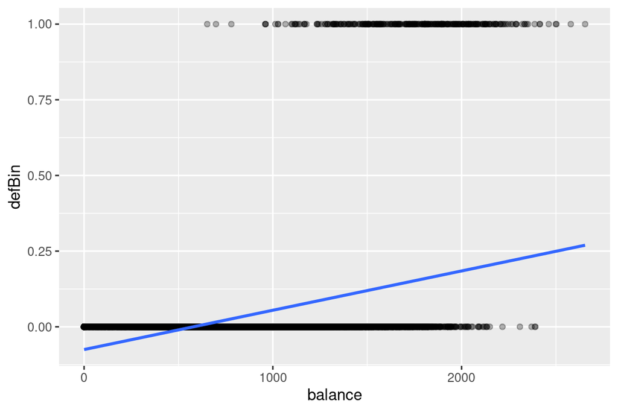

```r
ggplot(DefaultK, aes(x = balance, y = defBin)) +
  geom_point(alpha = 0.3) +
  geom_smooth(method = lm, formula = y ~ x, se = FALSE)
```

## Logistic Regression Link Function

- In **logistic regression**, the link function is the **logit:**
  $$\eta(u) = \log \left(\frac{u}{1-u} \right) = \text{logit}(u)$$
  - Henceforth $\log$ means natural log.
  - $\eta: (0,1) \longrightarrow \mathbb{R}$.
  - $\eta$ is invertible (Exercise):
    $$y = \log\left(\frac{u}{1-u}\right) \,\, \Leftrightarrow \,\, u =
    \frac{e^y}{1 + e^y}$$

## Logistic Regression Distribution

- In logistic regression, we assume the response $Y$ is binary.
- So for a given $X$, $Y \mid X$ is distributed as a **Bernoulli** random variable:
  $$\begin{align}
  \text{Pr}(Y = 1 \mid X) &= p \\
  \text{Pr}(Y = 0 \mid X) &= 1-p
  \end{align}$$
- Bernoulli is the same as Binomial with $n-1$.

## Logistic Regression Equation

Let $p(X)$ be the **predicted probability** $p(X) = \text{Pr}(Y = 1 \mid X)$. The logistic regression model predicts the logit of the predicted probability:

$$\log\left(\frac{p(X)}{1-p(X)} \right) = \beta_0 + \beta_1X_1 + \cdots +
\beta_pX_p$$

## Logistic Regression in R

```r
defMod2 <- glm(default ~ balance, data = Default, family = binomial)
summary(defMod2)
```

```
Call:
glm(formula = default ~ balance, family = binomial, data = Default)

Deviance Residuals:
    Min       1Q   Median       3Q      Max
-2.2697  -0.1465  -0.0589  -0.0221   3.7589

Coefficients:
              Estimate Std. Error z value Pr(>|z|)
(Intercept) -1.065e+01  3.612e-01  -29.49   <2e-16 ***
balance      5.499e-03  2.204e-04   24.95   <2e-16 ***
---
Signif. codes:  0 '***' 0.001 '**' 0.01 '*' 0.05 '.' 0.1 ' ' 1

(Dispersion parameter for binomial family taken to be 1)

    Null deviance: 2920.6  on 9999  degrees of freedom
Residual deviance: 1596.5  on 9998  degrees of freedom
AIC: 1600.5

Number of Fisher Scoring iterations: 8
```

## Exercise (Pairs)

```
                 Estimate   Std. Error   z value      Pr(>|z|)
(Intercept) -10.651330614 0.3611573721 -29.49221 3.623124e-191
balance       0.005498917 0.0002203702  24.95309 1.976602e-137
```

1. Write down the logistic regression prediction equation.
2. Compute the *predicted logit* for someone with a balance of 2400.
3. Compute the *predicted probability* of defaulting for someone with a balance of 2400.
4. Predict $Y$ when $X = 2400$.

## Plotting the model

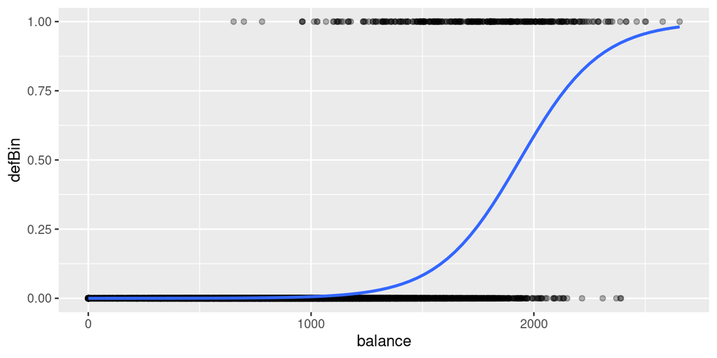

```r
ggplot(DefaultK, aes(x = balance, y = defBin)) +
  geom_point(alpha = 0.3) +
  geom_smooth(method = glm,
              method.args=list(family = binomial),
              formula = y ~ x, se = FALSE)
```

# Poisson Regression

## Example: Bikeshare data

```r
glimpse(Bikeshare)
```

```
Rows: 8,645
Columns: 15
$ season     <dbl> 1, 1, 1, 1, 1, 1, 1, 1, 1, 1, 1, 1, 1, 1, 1, 1, 1, 1, 1, 1, 1, 1, 1, 1, 1, 1, 1…
$ mnth       <fct> Jan, Jan, Jan, Jan, Jan, Jan, Jan, Jan, Jan, Jan, Jan, Jan, Jan, Jan, Jan, Jan,…
$ day        <dbl> 1, 1, 1, 1, 1, 1, 1, 1, 1, 1, 1, 1, 1, 1, 1, 1, 1, 1, 1, 1, 1, 1, 1, 1, 2, 2, 2…
$ hr         <fct> 0, 1, 2, 3, 4, 5, 6, 7, 8, 9, 10, 11, 12, 13, 14, 15, 16, 17, 18, 19, 20, 21, 2…
$ holiday    <dbl> 0, 0, 0, 0, 0, 0, 0, 0, 0, 0, 0, 0, 0, 0, 0, 0, 0, 0, 0, 0, 0, 0, 0, 0, 0, 0, 0…
$ weekday    <dbl> 6, 6, 6, 6, 6, 6, 6, 6, 6, 6, 6, 6, 6, 6, 6, 6, 6, 6, 6, 6, 6, 6, 6, 6, 0, 0, 0…
$ workingday <dbl> 0, 0, 0, 0, 0, 0, 0, 0, 0, 0, 0, 0, 0, 0, 0, 0, 0, 0, 0, 0, 0, 0, 0, 0, 0, 0, 0…
$ weathersit <fct> clear, clear, clear, clear, clear, cloudy/misty, clear, clear, clear, clear, cl…
$ temp       <dbl> 0.24, 0.22, 0.22, 0.24, 0.24, 0.24, 0.22, 0.20, 0.24, 0.32, 0.38, 0.36, 0.42, 0…
$ atemp      <dbl> 0.2879, 0.2727, 0.2727, 0.2879, 0.2879, 0.2576, 0.2727, 0.2576, 0.2879, 0.3485,…
$ hum        <dbl> 0.81, 0.80, 0.80, 0.75, 0.75, 0.75, 0.80, 0.86, 0.75, 0.76, 0.76, 0.81, 0.77, 0…
$ windspeed  <dbl> 0.0000, 0.0000, 0.0000, 0.0000, 0.0000, 0.0896, 0.0000, 0.0000, 0.0000, 0.0000,…
$ casual     <dbl> 3, 8, 5, 3, 0, 0, 2, 1, 1, 8, 12, 26, 29, 47, 35, 40, 41, 15, 9, 6, 11, 3, 11, …
$ registered <dbl> 13, 32, 27, 10, 1, 1, 0, 2, 7, 6, 24, 30, 55, 47, 71, 70, 52, 52, 26, 31, 25, 3…
$ bikers     <dbl> 16, 40, 32, 13, 1, 1, 2, 3, 8, 14, 36, 56, 84, 94, 106, 110, 93, 67, 35, 37, 36…
```

## First, try linear regression

```r
bikeMod1 <- lm(bikers ~ factor(workingday) + temp + weathersit, data = Bikeshare)
summary(bikeMod1)
```

```
Call:
lm(formula = bikers ~ factor(workingday) + temp + weathersit,
    data = Bikeshare)

Residuals:
    Min      1Q  Median      3Q     Max
-233.11  -77.88  -19.29   57.92  453.96

Coefficients:
                          Estimate Std. Error t value Pr(>|t|)
(Intercept)                  5.817      3.959   1.469 0.141822
factor(workingday)1         -1.301      2.752  -0.473 0.636417
temp                       299.091      6.478  46.167  < 2e-16 ***
weathersitcloudy/misty     -10.270      2.979  -3.448 0.000568 ***
weathersitlight rain/snow  -52.799      4.547 -11.612  < 2e-16 ***
weathersitheavy rain/snow  -34.316    118.522  -0.290 0.772183
---
Signif. codes:  0 '***' 0.001 '**' 0.01 '*' 0.05 '.' 0.1 ' ' 1

Residual standard error: 118.5 on 8639 degrees of freedom
Multiple R-squared:  0.2161,    Adjusted R-squared:  0.2157
F-statistic: 476.4 on 5 and 8639 DF,  p-value: < 2.2e-16
```

## Predict using `predict`

```r
predict(bikeMod1, data.frame(workingday = c(0, 1),
                             temp = c(0.7, 0), # normalized to [0,1]
                             weathersit = c("cloudy/misty", "heavy rain/snow")))
```

```
        1         2
204.91082 -29.80008
```

It doesn’t make sense to have negative bikers.

## Predicting counts

- The variable bikers is actually discrete, because it is a **count** of all the bikers.
- It is reasonable to assume that it has a Poisson distribution, for a fixed $X$.

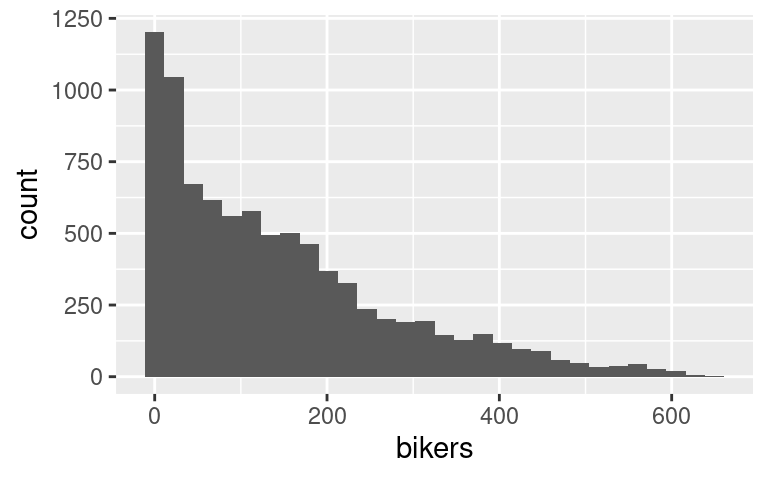

```r
ggplot(Bikeshare, aes(x = bikers)) + geom_histogram()
```

## Poisson Regression Distribution

- Use **Poisson regression** when the response $Y$ is a count.
- So for a given $X$, $Y \mid X$ is distributed as a **Poisson** random variable:
  $$\text{Pr}(Y = k \mid X) = \frac{e^{-\lambda} \lambda^k}{k!}, \text{where
  } k = 0,1,2,\ldots$$
- The corresponding link function is $\eta(u) = \log(u)$. (Why?)
- The regression equation gives the log of the predicted count.
  $$\log(X) = \beta_0 + \beta_1X_1 + \cdots + \beta_pX_p$$

## Poisson Regression in R

```r
bikeMod2 <- glm(bikers ~ factor(workingday) + temp + weathersit,
                data = Bikeshare, family = poisson)
summary(bikeMod2)
```

```
Call:
glm(formula = bikers ~ factor(workingday) + temp + weathersit,
    family = poisson, data = Bikeshare)

Deviance Residuals:
    Min       1Q   Median       3Q      Max
-21.336   -8.926   -2.168    4.834   29.525

Coefficients:
                           Estimate Std. Error  z value Pr(>|z|)
(Intercept)                3.885010   0.003231 1202.490  < 2e-16 ***
factor(workingday)1       -0.008888   0.001943   -4.574 4.78e-06 ***
temp                       2.129054   0.004789  444.587  < 2e-16 ***
weathersitcloudy/misty    -0.042219   0.002132  -19.805  < 2e-16 ***
weathersitlight rain/snow -0.432090   0.004023 -107.412  < 2e-16 ***
weathersitheavy rain/snow -0.760995   0.166681   -4.566 4.98e-06 ***
---
Signif. codes:  0 '***' 0.001 '**' 0.01 '*' 0.05 '.' 0.1 ' ' 1

(Dispersion parameter for poisson family taken to be 1)

    Null deviance: 1052921  on 8644  degrees of freedom
Residual deviance:  816754  on 8639  degrees of freedom
AIC: 869804

Number of Fisher Scoring iterations: 5
```

## Predict using `predict`

```r
predict(bikeMod2, data.frame(workingday = c(0, 1),
                             temp = c(0.7, 0), # normalized to [0,1]
                             weathersit = c("cloudy/misty", "heavy rain/snow")))
```

```
       1        2
5.333129 3.115127
```

## Predict using `predict` on the response scale

```r
predict(bikeMod2, data.frame(workingday = c(0, 1),
                             temp = c(0.7, 0), # normalized to [0,1]
                             weathersit = c("cloudy/misty", "heavy rain/snow")),
        type = "response")
```

```
        1         2
207.08490  22.53629
```

Check:

```r
exp(c(5.333129, 3.115127))
```

```
[1] 207.08493  22.53629
```